# Worksheet 1 - Scientific Visualization MVE080/MMG640

## Basics in Python, Jupyter, plotnine and how to visualize amounts

Name: Cheuk Bong Ho

This is the first worksheet in the course *Scientific Visualization*. This Jupyter notebook has three functions:

1. It describes the tasks.
2. It (sometimes) provides coding templates that you can use as a basis for your own code.
3. It is a template also for the report that you upload in Canvas.

The tasks are of various types: some are to read some text and then comment on it (no coding), and some are about creating visualizations using plotnine. Once you're finished with all the tasks, export this document as an HTML-file and upload it in Canvas. You are encouraged to discuss problems and solutions with your fellow students (in the class-room but also on CampusWire), but each student must solve all tasks by themselves and hand-in their own report. Notice that Jupyter notebooks use [Markdown](https://docs.github.com/en/github/writing-on-github/getting-started-with-writing-and-formatting-on-github/basic-writing-and-formatting-syntax#links) for writing text cells. Make sure you understand the basics. Later on you can also include $\LaTeX$ in your Markdown cells.

Throughout the assignment you shall use a Python workflow. If you are completely new to Python, take a look at this page. Python can do essentially all that MATLAB can, plus more. In this course we shall use Python in different contexts, starting with the [Jupyter Notebook interface](https://jupyter-notebook.readthedocs.io/en/stable/notebook.html).

Matrices and arrays are handled through the NumPy module. [Learn here](https://docs.scipy.org/doc/numpy/user/numpy-for-matlab-users.html) how NumPy is different from MATLAB.

The below loads the packages required for this homework.

```python
import numpy as np
import pandas as pd
from plotnine import *
from plotnine.data import mtcars # Classic example data set
from siuba.dply.forcats import *
import fabric

# A nice color palette for categorical data
cbPalette = ["#E69F00", "#56B4E9", "#009E73",
             "#F0E442", "#0072B2", "#D55E00",
             "#CC79A7", "#999999"]
```

## Task 1

Read Chapter 1-3 of [Fundamentals of Data Visualizations](https://clauswilke.com/dataviz/), then answer the questions below.

### Question 1.1

Describe the visualization concept *scales*.

### Answer 1.1

*Your answer here*

A scale defines a unique mapping between data and aesthetics. Importantly, a scale must be one-to-one, such that for each specific data value there is exactly one aesthetics value and vice versa. If a scale isn't one-to-one, then the data visualization becomes ambiguous.

### Question 1.2

In Figures 2.3 and 2.4 the same data is visualized in two different ways. Discuss the pros and cons of the two approaches. Which one do you prefer and why?

### Answer 1.2

*Your answer here*

Figure 2.3 can show the temperature change between month intervals but it can't present the precise temperature for a particular month. Figure 2.4 can show the temperature of each month but it can't show the temperature change between months. I would prefer figure 2.3 because it is more clean in terms of color.

### Question 1.3

Describe situations when *nonlinear axes* might be useful. When should they not be used?

### Answer 1.3

*Your answer here*

Nonlinear axes is useful when the data set contains numbers of very different magnitudes. Then, they may need nonlinear scales to show the ratios. They should not be used when the variables have a linear relationship. Then, linear scales can provide an accurate representation of the data.

### Question 1.4

In which situations could a *polar coordinate system* be useful?

### Answer 1.4

*Your answer here*

Polar coordinates can be useful for data of a periodic nature, such that data values at one end of the scale can be logically joined to data values at the other end.

## Task 2 - Tidy data, ggplot and distributions

Several graphics libraries such as ggplot2 and plotnine are at their best when the provided data is tidy. However, data is often not provided in a tidy format, hence being able to transform non-tidy data into tidy data is a crucial skill.

### Question 2.1

In the lecture I provided a small non-tidy dataset (code below).

```python
data1 = pd.DataFrame({"Site" : ["Stockholm", "Gothenburg", "London"],
                      "1999" : [13, 85, 77],
                      "2000" : [21, 31, 15]})
data1
```

|  | Site | 1999 | 2000 |
| --- | --- | --- | --- |
| 0 | Stockholm | 13 | 21 |
| 1 | Gothenburg | 85 | 31 |
| 2 | London | 77 | 15 |

Transform this small dataset into a tidy dataset. Print the table below (as I did above).

*Hint* [wide_to_long](https://pandas.pydata.org/docs/reference/api/pandas.wide_to_long.html)

```python
# Insert code here
tidy_data = pd.melt(data1, id_vars=["Site"], value_vars=["1999", "2000"])
tidy_data
# Remember to print the table
```

|  | Site | variable | value |
| --- | --- | --- | --- |
| 0 | Stockholm | 1999 | 13 |
| 1 | Gothenburg | 1999 | 85 |
| 2 | London | 1999 | 77 |
| 3 | Stockholm | 2000 | 21 |
| 4 | Gothenburg | 2000 | 31 |
| 5 | London | 2000 | 15 |

### Question 2.2

Datasets are often bigger than above. I have made a subset of the weather data used in the lecture non-tidy (available on the webpage).

```python
# If you have the data in the same directory as your notebook you can use
# path_data = "Weather_not_tidy.csv"
#path_data = "../Lecture2/Data/Weather_not_tidy.csv"
path_data = "Data/HW1/Weather_not_tidy.csv"
data_not_tidy = pd.read_csv(path_data)
data_not_tidy
```

|  | month | day | Temp2009 | hour_of_day | Temp2010 |
| --- | --- | --- | --- | --- | --- |
| 0 | Jan | 1 | -0.9 | 12 | -6.4 |
| 1 | Jan | 2 | -2.2 | 12 | -6.6 |
| 2 | Jan | 3 | 4.2 | 12 | -7.4 |
| 3 | Jan | 4 | -4.7 | 12 | 0.2 |
| 4 | Jan | 5 | -7.8 | 12 | -7.3 |
| ... | ... | ... | ... | ... | ... |
| 360 | Dec | 27 | 2.3 | 12 | -6.8 |
| 361 | Dec | 28 | -0.8 | 12 | -11.0 |
| 362 | Dec | 29 | 1.4 | 12 | -10.6 |
| 363 | Dec | 30 | -5.5 | 12 | -3.0 |
| 364 | Dec | 31 | -8.1 | 12 | -2.7 |

365 rows × 5 columns

Transform this dataset into a tidy dataset. Print the table below (as I did above)

```python
# Insert code here
tidy_data = pd.melt(data_not_tidy, id_vars=["month", "day"], value_vars=["Temp2009", "Temp2010", "hour_of_day"], col_level=0)
tidy_data
# Remember to print the table
```

|  | month | day | variable | value |
| --- | --- | --- | --- | --- |
| 0 | Jan | 1 | Temp2009 | -0.9 |
| 1 | Jan | 2 | Temp2009 | -2.2 |
| 2 | Jan | 3 | Temp2009 | 4.2 |
| 3 | Jan | 4 | Temp2009 | -4.7 |
| 4 | Jan | 5 | Temp2009 | -7.8 |
| ... | ... | ... | ... | ... |
| 1090 | Dec | 27 | hour_of_day | 12.0 |
| 1091 | Dec | 28 | hour_of_day | 12.0 |
| 1092 | Dec | 29 | hour_of_day | 12.0 |
| 1093 | Dec | 30 | hour_of_day | 12.0 |
| 1094 | Dec | 31 | hour_of_day | 12.0 |

1095 rows × 4 columns

## Distributions

For this part reading Chapter 7 and 9 in [Fundamentals of Data Visualizations](https://clauswilke.com/dataviz/) helps.

## Question 3.1

The benefit with tidy data is that it is easy to work with. For this task use the tidy weather dataset from above and choose three months and by **a density and histogram plot** visualize the differences in temperature between 2009 and 2010 for the chosen months in a readable manner. Make sure to print the visuals below.

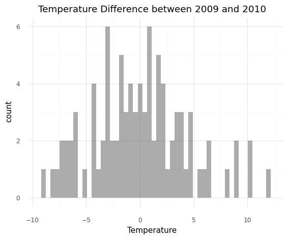

```python
# Insert code here for histogram
subdata = tidy_data.query("(month == 'Jun' or month == 'Jul' or month == 'Aug') and (variable == 'Temp2009' or variable =='Temp2010')")
i = subdata.query("variable == 'Temp2009'")
j = subdata.query("variable == 'Temp2010'")
diff = []
for (a, b) in zip(i['value'],j['value']):
    diff.append(b-a)
temp_diff = pd.DataFrame({"value": diff})
""""""
p2 = (ggplot(temp_diff, aes("value"))
    + geom_histogram(bins=50, alpha=0.5, position = "identity")
    + scale_fill_manual(values=cbPalette, name = "Variable")
    + labs(x = "Temperature", title = "Temperature Difference between 2009 and 2010")
    + theme_minimal())

p2
# Remember to print the visual
```

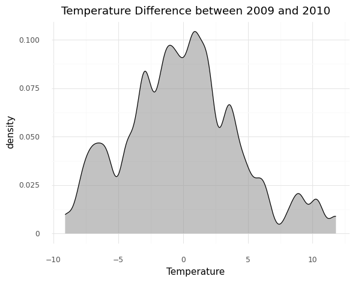

```python
# Insert code here for density plot
p1 = (ggplot(temp_diff, aes("value"))
    + geom_density(bw=0.5, alpha=0.6, fill = cbPalette[7])
    + labs(x = "Temperature", title = "Temperature Difference between 2009 and 2010")
    + theme_minimal())
p1
# Remember to print the visual
```

Provide a brief motivation for which plot (density and histogram) you find most readable.

*Your answer here*

I think the density plot is more readable because the plot looks more smooth.

### Question 3.2

In Lecture2 I used boxplots, error-bars, and violin plots to visualize fluctuations in winter temperature in Västerås. Now using the weather data above plot the temperature per month (like in Fig. 9.8 [here](https://clauswilke.com/dataviz/boxplots-violins.html)) using error-bars, boxplots and violin plots with data points. For each month plot the temperature for 2009 and 2010 next to each other (see example on webpage).

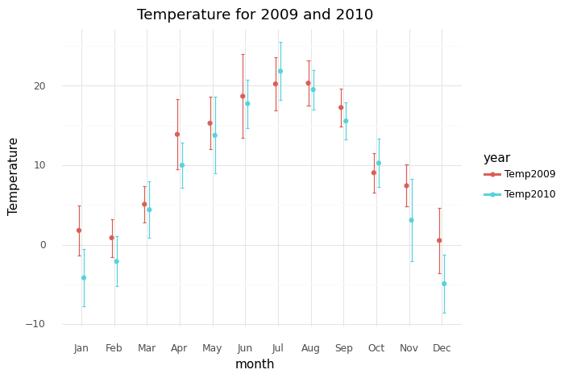

```python
# Insert code here using standard error
eb = pd.DataFrame({"month": [],
                   "year": [],
                   "mean": [],
                   "sd": []})
month = ['Jan', 'Feb', 'Mar', 'Apr', 'May', 'Jun', 'Jul', 'Aug', 'Sep', 'Oct', 'Nov', 'Dec']
year = ['Temp2009', 'Temp2010']
for i in month:
    for j in year:
        x = tidy_data.query("(month == @i) and (variable == @j)")
        #df = pd.concat([df, pd.DataFrame({"month": i, "year": j, "mean": np.mean(x.value), "sd": np.std(x.value)})])
        eb.loc[len(eb.index)] = [i, j, np.mean(x.value), np.std(x.value)]

p = (ggplot(eb, aes(fct_inorder(eb["month"]), "mean"))
    + geom_point(aes(color = "year"), position = position_dodge(0.3))
    + geom_errorbar(aes(ymin = "mean - sd", ymax = "mean + sd", color="year"), position=position_dodge(0.3), width=0.2)
    + labs(y = "Temperature", x = "month", title="Temperature for 2009 and 2010")
    + scale_fill_manual(values = cbPalette, name="Year")
    + theme_minimal())

p
# Remember to print the visual
```

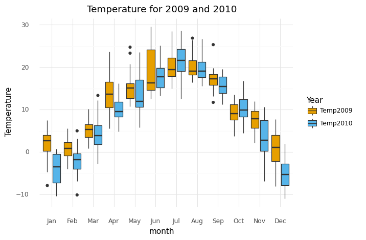

```python
# Insert code here using boxplots
box = tidy_data.query("(variable == 'Temp2009' or variable == 'Temp2010')")

p1 = (ggplot(box, aes(fct_inorder(box["month"]), y= "value"))
     + geom_boxplot(aes(fill = "variable"), position = position_dodge(0.9) )
     + labs(y = "Temperature", x = "month", title="Temperature for 2009 and 2010")
     + scale_fill_manual(values = cbPalette, name="Year")
     + theme_minimal())

p1
# Remember to print the visual
```

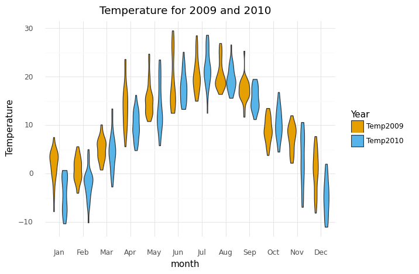

```python
# Insert code here using violin plot with dots
p1 = (ggplot(box, aes(fct_inorder(box["month"]), y= "value"))
     + geom_violin(aes(fill = "variable"), trim = True, position = position_dodge(0.9) )
     + labs(y = "Temperature", x = "month", title="Temperature for 2009 and 2010")
     + scale_fill_manual(values = cbPalette, name="Year")
     + theme_minimal()     )
p1
# Remember to print the visual
```

Briefly discuss the drawback with each approach (standard errors, boxplots, and violin plots).

**Write answer here**

For standard errors, it is not obvious what the points and error bars represent. This may confuse the readers.

For boxplots, it is hard to observe the detailed shape of distribution.

For violin plots, the quantitative value for the mean is not provided.

### Question 3.3

Some people argue that visuals should be as minimal as possible. On the webpage you have a bad example of a minimalist way to plot the min, median, and max temperature of each month in 2009 and 2010 using the dataset in Question 3.2 (where you hopefully have filtered out daily temperatures for 2009 and 2010). By **only** using geom_point recreate the visual (you do not need to recreate the title). **You are not allowed to transform the dataset**.

*Hint - Remember the stat argument in ggplot*

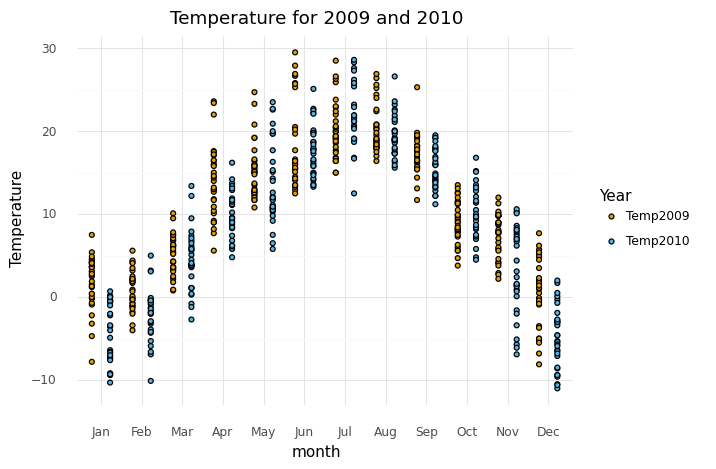

```python
# Insert code here
p1 = (ggplot(box, aes(fct_inorder(box["month"]), y= "value", fill = "variable"))
      + geom_point(stat = "identity", position = position_dodge(0.9))
      + labs(y = "Temperature", x = "month", title="Temperature for 2009 and 2010")
      + scale_fill_manual(values = cbPalette, name="Year")
      + theme_minimal()     )
p1

# Remember to print the visual
```

### Question 3.4

Using the full weather dataset on the webpage create two plots of your on choice. For example, you can compare winter temperatures across years, differences in night and day temperatures etc. For each visual provide a brief motivation on why your choice of visual (e.g violin or boxplot) is a good choice.

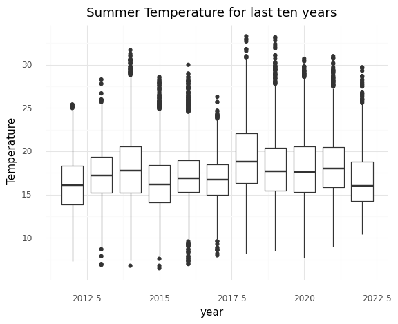

```python
# Insert code here
data_tidy = pd.read_csv("Data/HW1/Weather_tidy_full.csv")
summer = data_tidy.query("(month == 'Jun' or month == 'Jul' or month == 'Aug') and (year >= 2012)")

p1 = (ggplot(summer, aes(x = "year",y= "Temperature", group = "year"))
     + geom_boxplot()
     + labs(y = "Temperature", x = "year", title="Summer Temperature for last ten years")
     + theme_minimal())
p1
# Remember to print the visual
```

*Brief motivation*

The boxplot compares the summer temperature for the last ten years.

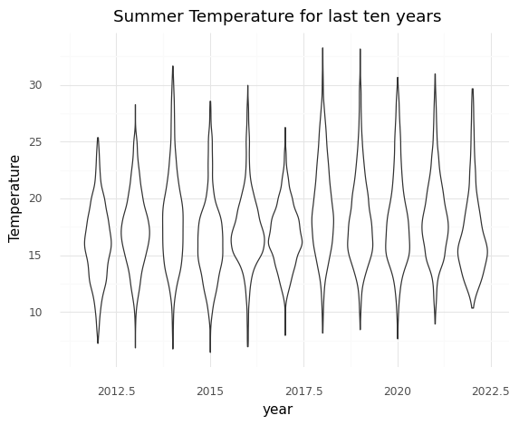

```python
# Insert code here
p1 = (ggplot(summer, aes(x = summer["year"],y= "Temperature", group = "year"))
     + geom_violin(trim = True, position = position_dodge(0.9) )
     + labs(y = "Temperature", x = "year", title="Summer Temperature for last ten years")
     + theme_minimal()     )
p1
# Remember to print the visual
```

*Brief motivation*

The violin plot compares the summer temperature for the last ten years.

## Amounts

For this part reading Chapter 6 in [Fundamentals of Data Visualizations](https://clauswilke.com/dataviz/) can help.

### Question 4.1

Barplots are the workhorse for plotting amounts. Create a dataframe with the values from Tab. 6.1 in the [course book](https://clauswilke.com/dataviz/visualizing-amounts.html), and recreate Fig. 6.1 and Fig. 6.3 in the course book.

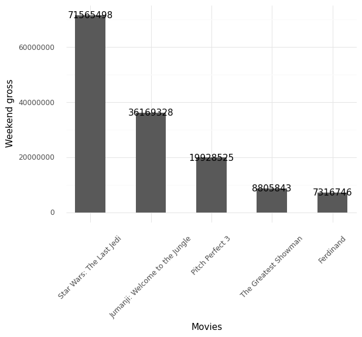

```python
# Insert code here for Fig. 6.1
movies = pd.DataFrame({"Rank": [1, 2, 3, 4, 5],
                      "Title": ["Star Wars: The Last Jedi", "Jumanji: Welcome to the Jungle", "Pitch Perfect 3", "The Greatest Showman", "Ferdinand"],
                      "Weekend_gross": [71565498, 36169328, 19928525, 8805843, 7316746]})


pos = movies["Title"].values[np.argsort(movies["Weekend_gross"])]
p = (ggplot(movies, aes("Title", "Weekend_gross"))
  + geom_bar(stat="identity", width = 0.5, position = position_dodge(0.7))
  + geom_text(aes(label = "Weekend_gross"))
  + labs(x = "Movies", y = "Weekend gross")
  + scale_x_discrete(limits=pos[::-1],expand = (0, 0.4))
  + theme_minimal()
  + theme(axis_text_x = element_text(angle = 45, hjust=0.1),
          legend_position="none"))
p
# Remember to print the visual
```

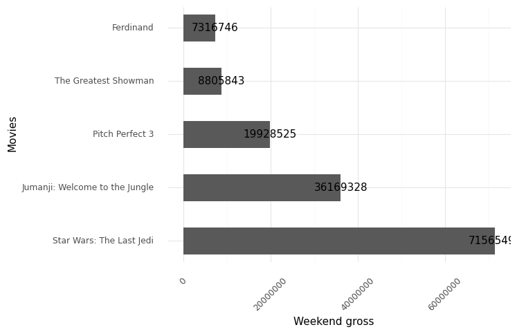

```python
# Insert code here for Fig. 6.2
p = (ggplot(movies, aes("Title", "Weekend_gross"))
  + geom_bar(stat="identity", width = 0.5, position = position_dodge(0.7))
  + geom_text(aes(label = "Weekend_gross"))
  + labs(x = "Movies", y = "Weekend gross")
  + scale_x_discrete(limits=pos[::-1],expand = (0, 0.4))
  + coord_flip()
  + theme_minimal()
  + theme(axis_text_x = element_text(angle = 45, hjust=0.1),
          legend_position="none"))
p
# Remember to print the visual
```

### Question 4.2

Often we want to highlight a specific column in a barplot. Using the same layout as in the most recent plot highlight the column of Jumanji in orange, and keep the remaining columns grey.

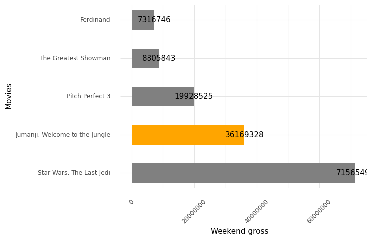

```python
# Insert code here
movies = movies.assign(
            highlight = lambda dataframe: dataframe['Title'].map(lambda title: True if title == "Jumanji: Welcome to the Jungle" else False)
            )
p = (ggplot(movies, aes("Title", "Weekend_gross", fill= "highlight"))
  + geom_bar(stat="identity", width = 0.5, position = position_dodge(0.7))
  + geom_text(aes(label = "Weekend_gross"))
  + labs(x = "Movies", y = "Weekend gross")
  + scale_x_discrete(limits=pos[::-1],expand = (0, 0.4))
  + coord_flip()
  + scale_fill_manual( values = ["grey", "orange"], guide = False )
  + theme_minimal()
  + theme(axis_text_x = element_text(angle = 45, hjust=0.1),
          legend_position="none"))
p

# Remember to print the visual
```

### Question 4.3

On the webpage I have uploaded a dataset on the number of marriages in Stockholm, Gothenburg, Malmo and rest of Sweden for 2020, 2015, 2010 and 2005. Using this dataset produce i) a visual where it is easy to see which year Stockholm had the second most marriages, and ii) a visual where it is easy to see how many more marriages there was in Stockholm compared to Gothenburg in 2015. **In each visual I want you to include the number of marriages for each city and year**.

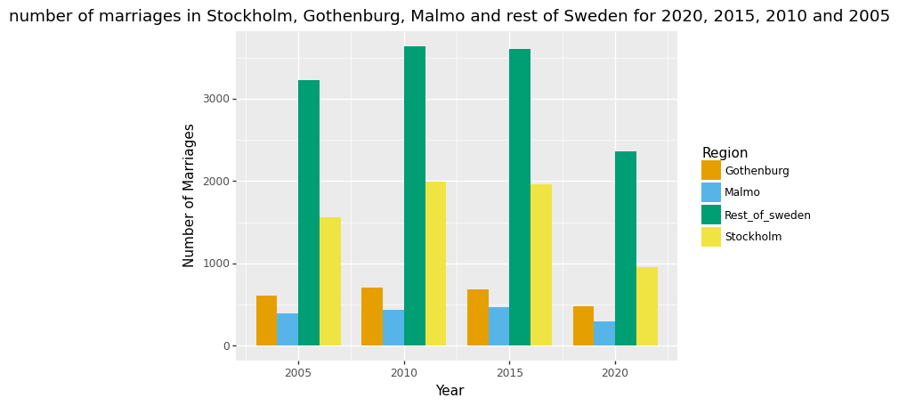

```python
# Insert code here for part i)
marriage = pd.read_csv("Data/HW1/Marriage.csv")

p = (ggplot(marriage, aes("year", "number_marriages", fill="region"))
  + geom_bar(width=4, stat = "identity", position="dodge")
  + labs(x = "Year", y = "Number of Marriages", title = "number of marriages in Stockholm, Gothenburg, Malmo and rest of Sweden for 2020, 2015, 2010 and 2005")
  + scale_fill_manual(values = cbPalette, name="Region") )
p
# Remember to print the visual
```

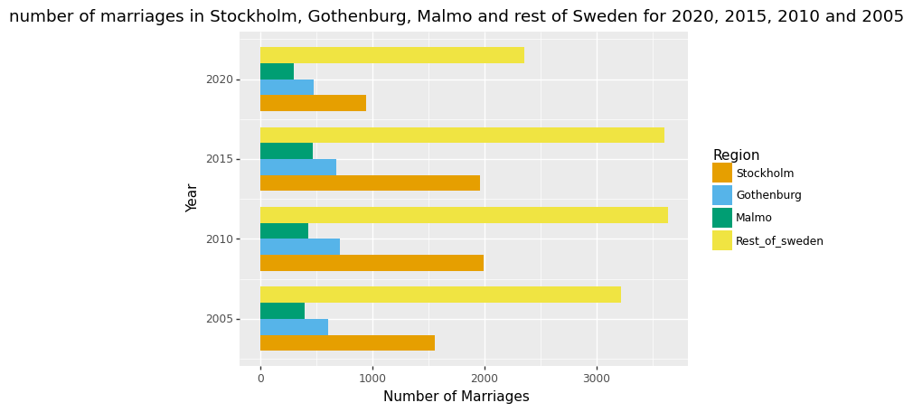

```python
# Insert code here for part ii)
p = (ggplot(marriage, aes("year", "number_marriages", fill=fct_inorder(marriage["region"])))
  + geom_bar(width=4, stat = "identity", position="dodge")
  + labs(x = "Year", y = "Number of Marriages", title = "number of marriages in Stockholm, Gothenburg, Malmo and rest of Sweden for 2020, 2015, 2010 and 2005")
  + scale_fill_manual(values = cbPalette, name="Region")
  + coord_flip()
    )
p

# Remember to print the visual
```

### Question 4.4

When plotting the mobile operating system data in the lectures I used usied a classical barplot. Another way which makes it easy to track the trend over several years or across companies is a common line-plot. Using the dataset on the webpage recreate the present on the webpage.

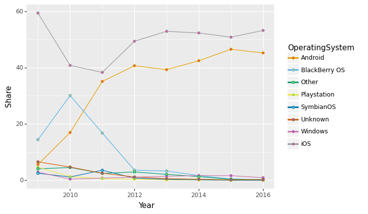

```python
# Insert code here
os_data = pd.read_csv("Data/mobile_os_market_share.csv")

p = (ggplot(os_data, aes("Year", "Share", fill="OperatingSystem"))
     + geom_line(aes(color="OperatingSystem"))
     + geom_point(aes(color="OperatingSystem"))
     + scale_color_manual(values=cbPalette)
    )
p
# Remember to print the visual
```

### Question 4.5

In the lecture I provided data on European nations median lifespan. Now using the full dataset (on the webpage) provided on the webpage select a subset of countries and visualize i) life-expectancy across a timespan of your choice and ii) life expectancy in 2020. Provide a brief motivation for your choice of visual.

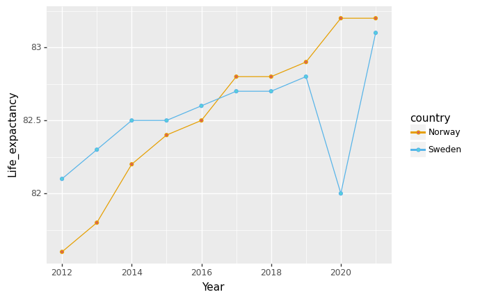

```python
# Insert code here for part1
data_life = pd.read_csv("Data/Life_tidy.csv")
d = data_life.query("Year >= 2012 and (country == 'Sweden' or country == 'Norway')")

p = (ggplot(d, aes("Year", "Life_expactancy", fill="country"))
     + geom_line(aes(color="country"))
     + geom_point(aes(color="country"))
     + scale_color_manual(values=cbPalette)
    )
p
# Remember to print the visual
```

*Brief motivation*

The line plot compares the life expactancy between Norway and Sweden for the last ten years.

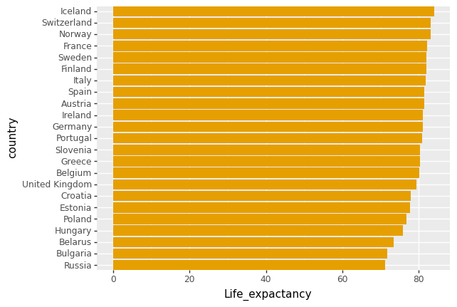

```python
# Insert code here for part2
d = data_life.query("Year == 2020")

pos = d["country"].values[np.argsort(d["Life_expactancy"])]
p = (ggplot(d, aes("country", "Life_expactancy"))
     + geom_col(fill = cbPalette[0])
     + scale_x_discrete(limits=pos,expand = (0, 0.4))
     + coord_flip()
     )

p
# Remember to print the visual
```

*Brief motivation*

The barplot shows the life expactacy of countries from the highest to lowest.